# Final Project

#### SARIMA(1, 1, 2)(2, 1, 0)_12

```r
# ML METHOD
base_112_ML <- Parameter.estimation(Data_ts_agg,c(1,1,2),c(2,1,0),method="ML",'33')
```

```
##
##  Shapiro-Wilk normality test
##
## data:  res.model
## W = 0.95424, p-value = 0.01305
```

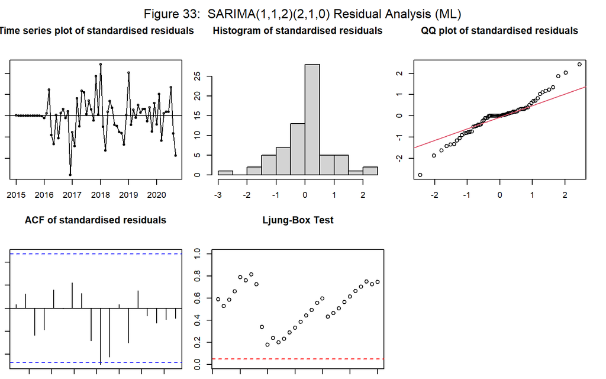

```
##
## z test of coefficients:
##
##      Estimate Std. Error z value  Pr(>|z|)
## ar1  -0.52569    0.50196 -1.0473  0.294977
## ma1  -0.32004    0.51600 -0.6202  0.535107
## ma2  -0.30295    0.44495 -0.6809  0.495960
## sar1 -0.70596    0.16101 -4.3847 1.162e-05 ***
## sar2 -0.42545    0.14098 -3.0179  0.002546 **
## ---
## Signif. codes:  0 '***' 0.001 '**' 0.01 '*' 0.05 '.' 0.1 ' ' 1
```

It can be seen for the above model none of the AR or MA values for the ARIMA component are significant. It can be seen in the residual analysis, there is no obvious trend in the residuals plot. However using the histogram of residuals and the QQ plot, it does not seem the residuals are normally distributed. This can be further seen by the Shapiro Wilks t-test which returned a p-value of 0.013 which is less than 0.05. However there is no significant lags in the ACF plot and all p values are above the confidence interval in the Ljung-Box test. The CSS method will be used because the residuals were not normally distributed.

```r
# CSS METHOD
base_112_CSS <- Parameter.estimation(Data_ts_agg,c(1,1,2),c(2,1,0),method="CSS",'34')
```

```
##
##  Shapiro-Wilk normality test
##
## data:  res.model
## W = 0.82263, p-value = 1.18e-07
```

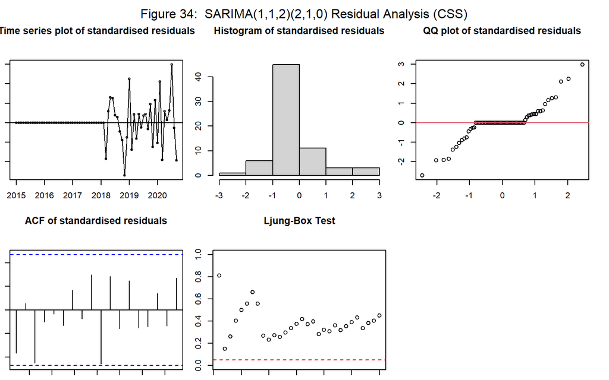

```
##
## z test of coefficients:
##
##        Estimate Std. Error  z value Pr(>|z|)
## ar1   0.0035225  0.0203324   0.1732   0.8625
## ma1  -1.1662376  0.1202955  -9.6948   <2e-16 ***
## ma2  -0.1153427  0.1619569  -0.7122   0.4764
## sar1 -0.6806481  0.0209258 -32.5268   <2e-16 ***
## sar2 -0.3865264  0.0212518 -18.1879   <2e-16 ***
## ---
## Signif. codes:  0 '***' 0.001 '**' 0.01 '*' 0.05 '.' 0.1 ' ' 1
```

#### SARIMA(2, 1, 1)(2, 1, 0)_12

```r
# ML METHOD
base_211_ML <- Parameter.estimation(Data_ts_agg,c(2,1,1),c(2,1,0),method="ML",'35')
```

```
##
##  Shapiro-Wilk normality test
##
## data:  res.model
## W = 0.95635, p-value = 0.01692
```

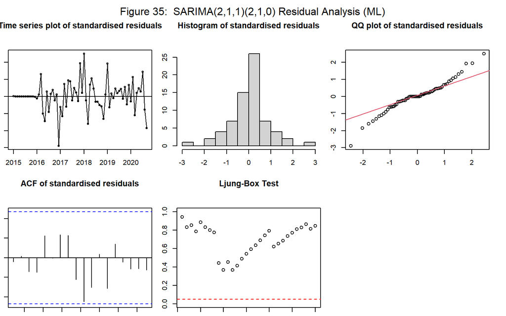

```
##
## z test of coefficients:
##
##       Estimate Std. Error  z value  Pr(>|z|)
## ar1   0.116663   0.139368   0.8371  0.402544
## ar2   0.276976   0.137889   2.0087  0.044570 *
## ma1  -0.999867   0.083334 -11.9984 < 2.2e-16 ***
## sar1 -0.641745   0.150041  -4.2771 1.893e-05 ***
## sar2 -0.405200   0.139817  -2.8981  0.003755 **
## ---
## Signif. codes:  0 '***' 0.001 '**' 0.01 '*' 0.05 '.' 0.1 ' ' 1
```

```r
# CSS METHOD
base_211_CSS <- Parameter.estimation(Data_ts_agg,c(2,1,1),c(2,1,0),method="CSS",'36')
```

```
##
##  Shapiro-Wilk normality test
##
## data:  res.model
## W = 0.82392, p-value = 1.284e-07
```

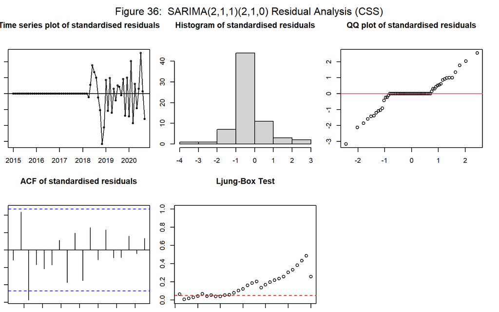

```
##
## z test of coefficients:
##
##       Estimate Std. Error  z value  Pr(>|z|)
## ar1  -0.223200   0.077451  -2.8818  0.003954 **
## ar2  -0.466185   0.037515 -12.4266 < 2.2e-16 ***
## ma1  -1.250171   0.021429 -58.3394 < 2.2e-16 ***
## sar1 -0.728645   0.021386 -34.0707 < 2.2e-16 ***
## sar2 -0.405981   0.018689 -21.7233 < 2.2e-16 ***
## ---
## Signif. codes:  0 '***' 0.001 '**' 0.01 '*' 0.05 '.' 0.1 ' ' 1
```

#### SARIMA(0, 1, 5)(2, 1, 0)_12

```r
base_015_ML <- Parameter.estimation(Data_ts_agg,c(0,1,5),c(2,1,0),method="ML",'37')
```

```
##
##  Shapiro-Wilk normality test
##
## data:  res.model
## W = 0.95543, p-value = 0.0151
```

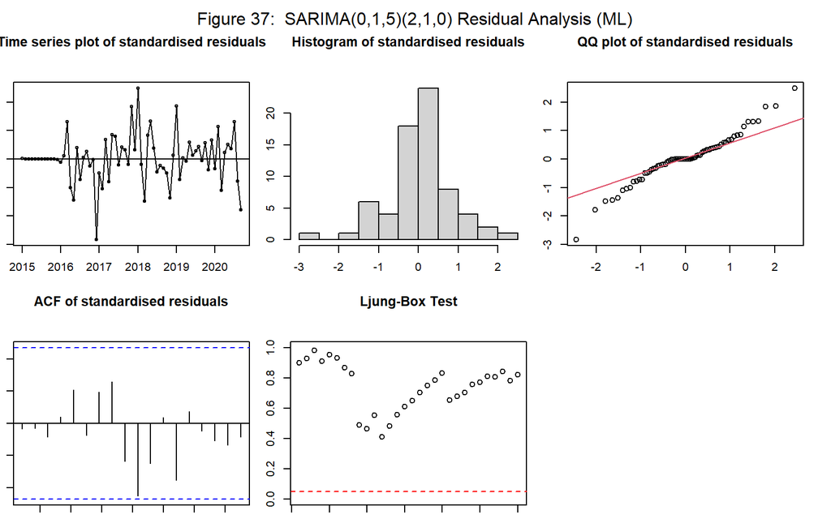

```
##
## z test of coefficients:
##
##        Estimate Std. Error z value  Pr(>|z|)
## ma1  -0.8730969  0.1743786 -5.0069 5.531e-07 ***
## ma2   0.1954657  0.1936328  1.0095  0.312751
## ma3  -0.2699945  0.2430327 -1.1109  0.266595
## ma4  -0.0582800  0.2360817 -0.2469  0.805014
## ma5   0.0060052  0.1250764  0.0480  0.961707
## sar1 -0.6187762  0.1588614 -3.8951 9.817e-05 ***
## sar2 -0.3873829  0.1445589 -2.6798  0.007368 **
## ---
## Signif. codes:  0 '***' 0.001 '**' 0.01 '*' 0.05 '.' 0.1 ' ' 1
```

It can be seen for the above model the MA(1) value for the ARIMA component are significant and none of the others. It can be seen in the residual analysis, there is no obvious trend in the residuals plot. However using the histogram of residuals and the QQ plot, it does not seem the residuals are normally distributed. This can be further seen by the Shapiro Wilks t-test which returned a p-value of 0.015 which is less than 0.05. However there is no significant lags in the ACF plot and all p values are above the confidence interval in the Ljung-Box test. The CSS method will be used because the residuals were not normally distributed.

```r
base_015_CSS <- Parameter.estimation(Data_ts_agg,c(0,1,5),c(2,1,0),method="CSS",'38')
```

```
##
##  Shapiro-Wilk normality test
##
## data:  res.model
## W = 0.7918, p-value = 1.726e-08
```

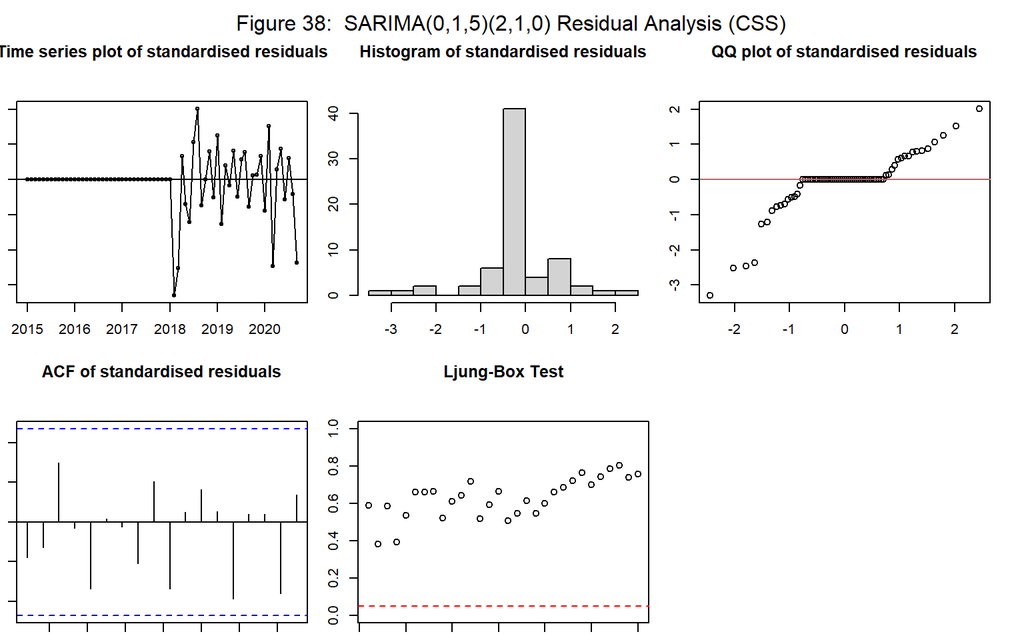

```
##
## z test of coefficients:
##
##      Estimate Std. Error z value  Pr(>|z|)
## ma1  -0.50653    0.15146 -3.3443 0.0008249 ***
## ma2   0.25607    0.17834  1.4358 0.1510465
## ma3  -0.57897    0.15413 -3.7563 0.0001725 ***
## ma4   0.17350    0.16677  1.0403 0.2981929
## ma5   0.59534    0.14348  4.1493 3.335e-05 ***
## sar1 -0.63321    0.10866 -5.8275 5.628e-09 ***
## sar2 -0.61838    0.13624 -4.5391 5.651e-06 ***
## ---
## Signif. codes:  0 '***' 0.001 '**' 0.01 '*' 0.05 '.' 0.1 ' ' 1
```

#### SARIMA(0, 1, 2)(2, 1, 0)_12

```r
base_012_ML <- Parameter.estimation(Data_ts_agg,c(0,1,2),c(2,1,0),method="ML",'39')
```

```
##
##  Shapiro-Wilk normality test
##
## data:  res.model
## W = 0.95775, p-value = 0.02012
```

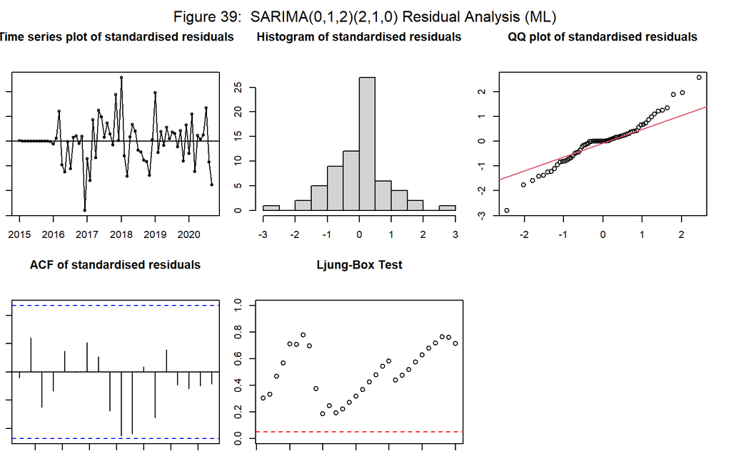

```
##
## z test of coefficients:
##
##       Estimate Std. Error z value  Pr(>|z|)
## ma1  -0.821572   0.149305 -5.5026 3.741e-08 ***
## ma2   0.048129   0.150831  0.3191  0.749658
## sar1 -0.712262   0.162707 -4.3776 1.200e-05 ***
## sar2 -0.416974   0.144295 -2.8897  0.003856 **
## ---
## Signif. codes:  0 '***' 0.001 '**' 0.01 '*' 0.05 '.' 0.1 ' ' 1
```

It can be seen for the above model the MA(1) value for the ARIMA component are significant and none of the others. It can be seen in the residual analysis, there is no obvious trend in the residuals plot. However using the histogram of residuals and the QQ plot, it does not seem the residuals are normally distributed. This can be further seen by the Shapiro Wilks t-test which returned a p-value of 0.02 which is less than 0.05. However there is no significant lags in the ACF plot and all p values are above the confidence interval in the Ljung-Box test. The CSS method will be used because the residuals were not normally distributed.

```r
base_012_CSS <- Parameter.estimation(Data_ts_agg,c(0,1,2),c(2,1,0),method="CSS",'40')
```

```
##
##  Shapiro-Wilk normality test
##
## data:  res.model
## W = 0.80252, p-value = 3.298e-08
```

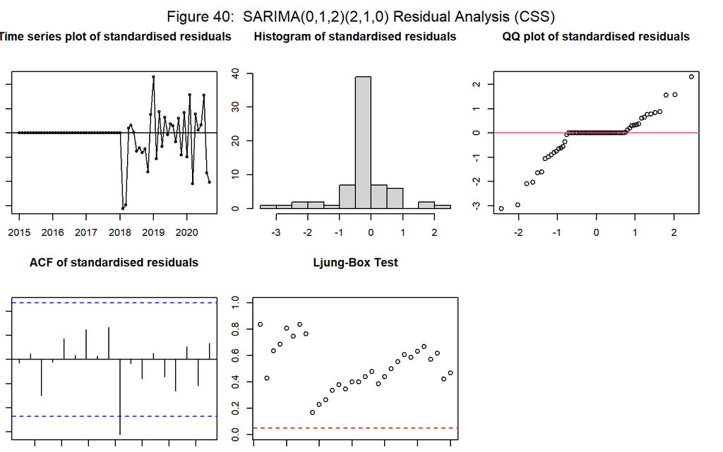

```
##
## z test of coefficients:
##
##       Estimate Std. Error z value  Pr(>|z|)
## ma1  -0.516560   0.136887 -3.7736 0.0001609 ***
## ma2  -0.024451   0.139904 -0.1748 0.8612620
## sar1 -0.597292   0.136534 -4.3747 1.216e-05 ***
## sar2 -0.379309   0.118047 -3.2132 0.0013126 **
## ---
## Signif. codes:  0 '***' 0.001 '**' 0.01 '*' 0.05 '.' 0.1 ' ' 1
```

It can be seen for the above model using the CSS method, only the MA(1) parameter for the ARIMA component are significant. It can be seen in the residual analysis, there is no obvious trend in the residuals plot. However using the histogram of residuals and the QQ plot, it does not seem the residuals are normally distributed. This can be further seen by the Shapiro Wilks t-test which returned a p-value of ~0 which is less than 0.05. There is also a significant lag in the ACF plot and all p values are above the confidence interval in the Ljung-Box test. This is likely a less promising model.